# Homework 2

Author

Will Tirone

### Question 1 (Sta 644 required, otherwise EC)

One way we can deal with overdispersion in a Poisson regression model is by using a Negative Binomial distribution instead. There is a clever parameterization that helps with the interpretability of this model. If we define

$$\begin{aligned}
Y~|~Z &\sim \text{Pois}(\lambda \, Z) \\
Z &\sim \text{Gamma}(\theta, \, \theta)
\end{aligned}$$

*show* that the marginal distribution of $Y = \int_0^\infty [Y~|~Z]~[Z] ~ dz$ will be negative binomial with,

$$\begin{aligned}
E(Y) &= \lambda \\
Var(Y) &= \lambda + \lambda^2/\theta
\end{aligned}$$

### Question 2

*Assume we have a process defined by $y_t = 3 + 2\,t + 0.5 \, y_{t-1} + w_t$ where $w_t \overset{iid}{\sim} \mathcal{N}(0, \sigma^2_w)$*

1. *Is $y_t$ stationary ? Show why or why not.*

2. *Is $y_t$ stationary after 1st order differencing (i.e. is $y_t - y_{t-1}$ stationary)? Show why or why not.*

### Question 3

*Let $y_t = 1 + 0.5 \, y_{t-1} + 0.5 \, w_{t-1} + w_t$, where $w_t \overset{iid}{\sim} \mathcal{N}(0,\sigma^2_w)$.*

1. *Find $E(y_t)$*

2. *Find $\text{Var}(y_t)$*

3. *Find autocovariance function of $y_t$, $\gamma_y(h)$*

4. *Find the autocorrelation function of $y_t$, $\rho_y(h)$*

5. *Plot or sketch the ACF of $y_t$ for lags 1 through 5*
6. *Rewrite ${\bf y} = \{y_t\}$ as a multivariate normal distribution, clearly define both ${\bf \mu}$ and ${\bf \Sigma}$*

### Question 4

1. *Write a function to simulate an AR(1) process for an arbitrary $\phi$, assume that $y_0 = 0$*

```r
AR1 = function(delta, phi, S) {

  time_data = c()
  time = 1:S

  for (t in time) {

    w_t = rnorm(1, 0, 1)

    if (t == 1) {
      y_1 = delta + phi * 0 + w_t
      time_data = c(time_data, y_1)
    } else {
      y_t = delta + phi * time_data[t-1] + w_t
      time_data = c(time_data, y_t)
    }
  }

  time_df = data.frame(time, time_data) |>
    as_tsibble(index = time)

  return(time_df)

}
```

2. *Pick a value of $\phi$ such that $0 < \phi < 1$, generate at least 1000 samples from this process and compare the empirical mean and variance to the appropriate theoretical values.*

Below, we see a simulated mean of 3.951. Using the formula for the expectation derived in class, $E(y_t) = \frac{\delta}{1-\phi} = 4$ with $\delta = 2, \phi=0.5$ so it looks like we’re on the right track.

```r
set.seed(829)
sim = AR1(delta = 2, phi = 0.5, S=2000)
sim_mean = mean(sim$time_data)
print(sim_mean)
```

```
[1] 3.951142
```

c. *Compute the empirical ACF for your simulation, compare this to the values of theoretical autocorrelation function.*

Here, I used the theoretical autocorrelation for an AR(1) process which is simply $\rho(h) = \phi^h$ and compared to the ACF from our simulation. They look very similar again. Below, the theoretical values are the red dots on the plot.

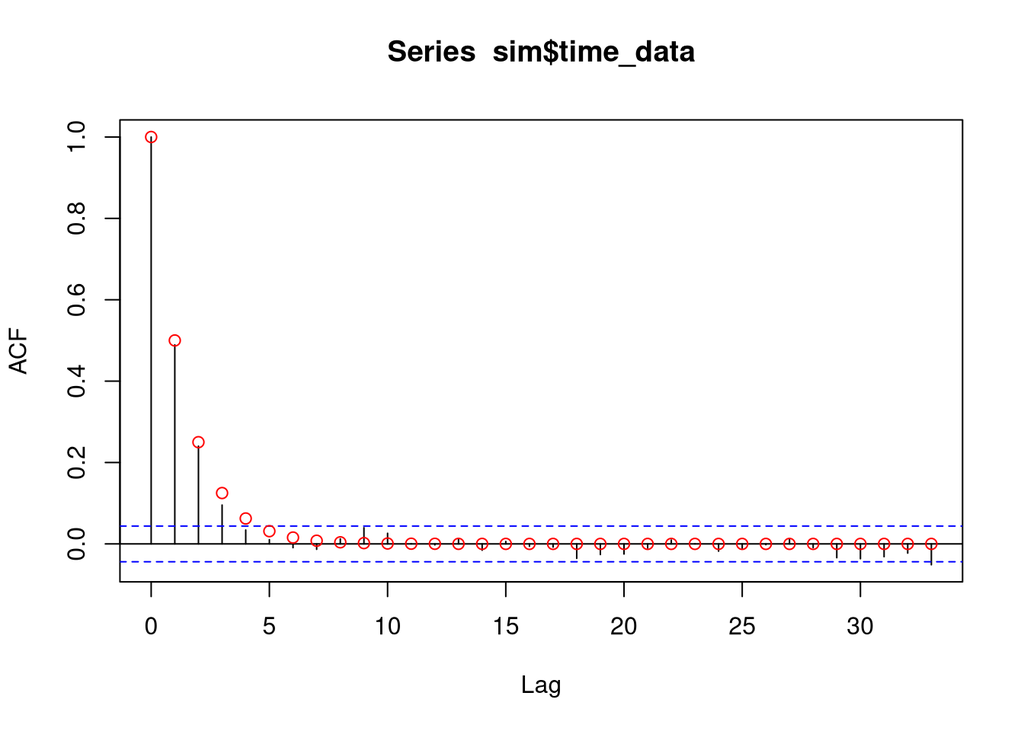

```r
time = c(0:33)
phi = rep(0.5, 34)
theoretical_acf = phi^time

acf_result = acf(sim$time_data, plot=FALSE)
plot(acf_result)
points(x = acf_result$lag, y = theoretical_acf, type = 'p', col = 'red')
```

4. *Repeat your simulation in part b. at least 100 times, create a **visualization** to compare your empirical means and variances to the appropriate theoretical values.*

Using $\delta = 2$ and $\phi = 0.5$, the theoretical mean is again 4 and the theoretical variance = $\frac{1}{1-.25} = 1.333$ since we drew $w_t \sim N(0,1)$. Visualizing this, we see that our values in repeated iterations of the theoretical values to the empirical values confirms that our process worked as intended.

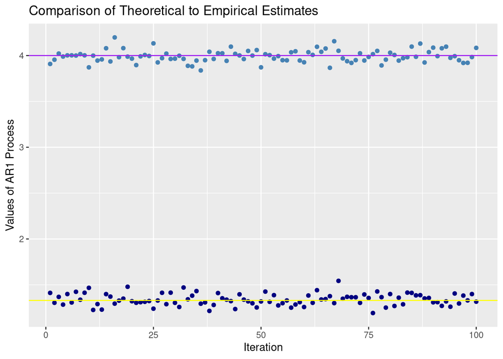

```r
emp_mean = c()
emp_variance = c()

for (i in 1:100) {
  sim = AR1(delta = 2, phi = 0.5, S=1000)
  emp_mean = c(emp_mean, mean(sim$time_data))
  emp_variance = c(emp_variance, var(sim$time_data))
}

empirical_df = data.frame(emp_mean, emp_variance, iter=1:100)

empirical_df |>
  ggplot() +
  geom_point(aes(x=iter, y=emp_mean), col='steelblue') +
  geom_point(aes(x=iter, y=emp_variance), col='navy') +
  geom_hline(yintercept = c(1.33, 4), color = c('yellow', 'purple')) +
  labs(
    y = "Values of AR1 Process",
    x = "Iteration",
    title = "Comparison of Theoretical to Empirical Estimates"
  )
```

### Question 5

1. *Write a function to simulate an MA(1) process for an arbitrary $\theta$, assume that $y_0 = 0$.*

```r
MA1 = function(delta, theta, S) {

  time_data = c()
  w = c()
  time = 1:S

  for (t in time) {

    w_t = rnorm(1, 0, 1)

    if (t == 1) {
      y_1 = delta + w_t
      time_data = c(time_data, y_1)
      w = c(w, w_t)
    } else {
      y_t = delta + w_t + theta * w[t-1]
      time_data = c(time_data, y_t)
      w = c(w, w_t)
    }
  }

  time_df = data.frame(time, time_data) |>
    as_tsibble(index = time)

  return(time_df)

}
```

2. *Pick a value of $\theta$, generate at least 1000 samples from this process and compare the empirical mean and variance to the appropriate theoretical values.*

```r
set.seed(829)
MA_sim = MA1(delta = 2, theta = 2, S=5000)
MA_sim_mean = mean(MA_sim$time_data)
print(MA_sim_mean)
```

```
[1] 1.941515
```

3. *Compute the empirical ACF for your simulation, compare this to the values of theoretical autocorrelation function.*

   With a simple comparison, we see the theoretical results match very closely to the empirical ACF, with the theoretical results showing as red dots below.

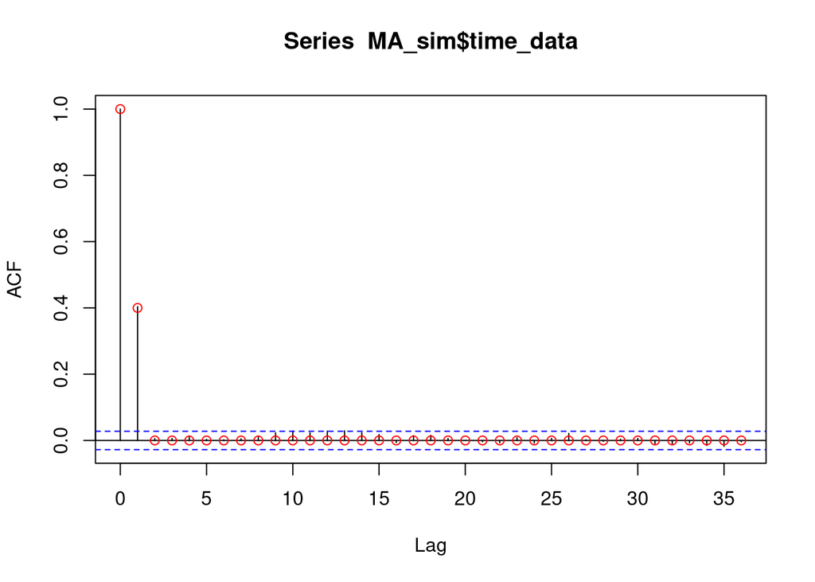

```r
MA_theoretical_acf <- c(1, 2/5, rep(0, 35))
acf_result <- acf(MA_sim$time_data, plot=FALSE)
plot(acf_result)
points(x = acf_result$lag, y = MA_theoretical_acf, type = 'p', col = 'red')
```

4. *Repeat your simulation in part b. at least 100 times, create a **visualization** to compare your empirical means and variances to the appropriate theoretical values.*

Just copying and pasting code from Q4), but changing the theoretical values. With an MA(1) process, the theoretical mean = $\delta = 2$ and the variance = $1(1 + 4) = 5$ since we again drew from $w_t \sim N(0,1)$. However, the variance of the variance is larger than the variance of the mean, which is interesting.

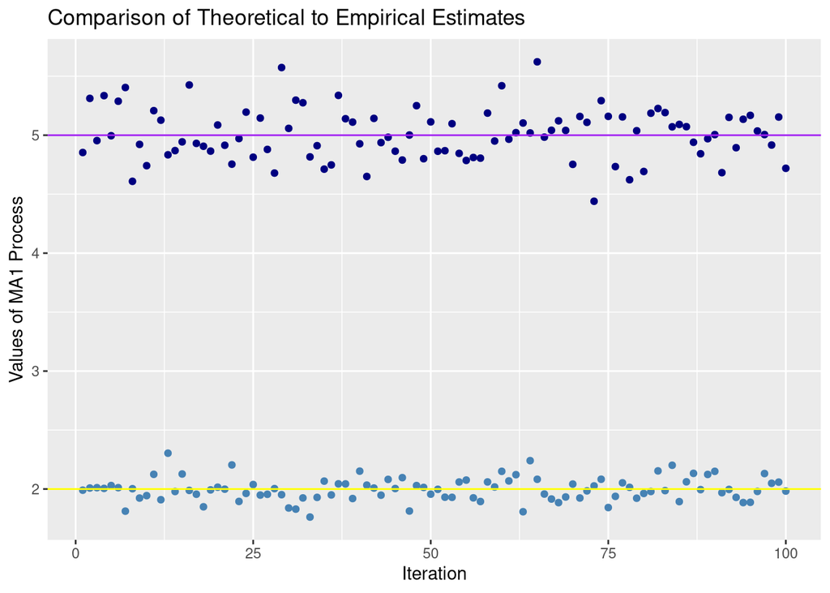

```r
emp_mean = c()
emp_variance = c()

for (i in 1:100) {
  sim = MA1(delta = 2, theta = 2, S=1000)
  emp_mean = c(emp_mean, mean(sim$time_data))
  emp_variance = c(emp_variance, var(sim$time_data))
}

empirical_df = data.frame(emp_mean, emp_variance, iter=1:100)

empirical_df |>
  ggplot() +
  geom_point(aes(x=iter, y=emp_mean), col='steelblue') +
  geom_point(aes(x=iter, y=emp_variance), col='navy') +
  geom_hline(yintercept = c(2, 5), color = c('yellow', 'purple')) +
  labs(
    y = "Values of MA1 Process",
    x = "Iteration",
    title = "Comparison of Theoretical to Empirical Estimates"
  )
```

### Question 6

*The `tsibbledata` package contains a dataset called `global_economy` which contains economic indicators featured by the World Bank from 1960 to 2017.*

1. *Pick a country other than Australia from the 263 provided countries and fit an appropriate ARIMA model to the `Population` data provided. Choose and justify your choice of $p$, $d$, and $q$. Be sure to include any EDA and residual analyses you perform.*

```r
pop = tsibbledata::global_economy |>
  filter(Country == "Australia")
```

2. *Compare your results to the model choosen automatically by `fable::ARIMA()`. If the models are not the same compare the model fit of the two results: specifically address how similar they are and which did better.*